# Validation of synthetic data algorithm

Jason T. Serviss

2019-02-19

```r
#PACKAGES
packages <- c(
  "CIMseq","CIMseq.data", "CIMseq.testing", "printr", "ggthemes", "tibble",
  "stringr", "dplyr", "purrr", "tidyr", "ggplot2", "matrixStats", "readr"
)
purrr::walk(packages, library, character.only = TRUE)
rm(packages)

#FUNCTIONS
#cpm normalization without adding 1 that works on both matrices and tibbles with
#genes as rows and cells as columns
norm <- function(counts) {
  if(all(class(counts) == c("tbl_df", "tbl", "data.frame"))) {
    mat <- counts %>%
      as.data.frame() %>%
      column_to_rownames("gene") %>%
      as.matrix()

    t(t(mat) / colSums(mat) * 10^6) %>%
      matrix_to_tibble("gene")
  } else if(class(counts) == "matrix") {
    t(t(counts) / colSums(counts) * 10^6)
  }
}

foldChangePerClass <- function(counts, classes) {
  uGroups <- unique(classes$class)

  res <- sapply(1:length(uGroups), function(x) {
    samplesA <- filter(classes, class == uGroups[x])$sample
    samplesB <- filter(classes, class != uGroups[x])$sample
    a <- rowMeans2(counts[, colnames(counts) %in% samplesA])
    b <- rowMeans2(counts[, colnames(counts) %in% samplesB])
    a / b
  })
  colnames(res) <- uGroups
  rownames(res) <- rownames(counts)
  return(res)
}
```

The synthetic multiplets are based on the mixing of real synthetic singlets. The algorithm for generating the synthetic multiplets works as follows: Two singlets from each cell type contributing to the multiplet are randomly selected. The fraction of input into the multiplet can be adjusted so that, e.g. cell type A only contributes half of what cell type B contributes to the multiplet, by multiplying the singlet counts per million values with the desired fraction of input (fractions must sum to 1). The sum of counts per million is subsequently calculated for each gene providing the counts per million of the synthesized multiplet.

Here we utilize the sorted cell line dataset to generate multiplets from the singlets. The synthesized multiplets are then compared to the real multiplets to acertain the quality of the *in silico* synthesis.

### Synthesize 10 multiplets per combination.

We begin by synthesizing ten multiplet per cell line combination, i.e. a A375-HCT116, A375-HOS, and HCT116-HOS multiplet.

```r
s <- str_detect(colnames(SCM.Counts), "^s")
sng <- SCM.Counts[, s]
classes <- slice(SCM.Meta, match(colnames(sng), SCM.Meta$sample))$cellTypes
n <- 10

fractions <- unique(classes) %>%
  sort() %>%
  combn(2) %>%
  as.data.frame(stringsAsFactors = FALSE) %>%
  {paste(.[1, ], .[2, ], sep = "-")} %>%
  c(., "A375-HCT116-HOS") %>%
  setNames(., .) %>%
  map(function(x) {
    vec <- rep(0, length(unique(classes)))
    names(vec) <- unique(classes)
    sp <- str_split(x, "-")[[1]]
    vec[names(vec) %in% sp] <- 1/length(sp)
    vec[!names(vec) %in% sp] <- (1 - sum(vec)) / length(which(vec == 0))
    vec
  }) %>%
  rep(., n)


synth <- map(1:length(fractions), function(i) {
    syntheticMultipletsFromCounts(norm(sng), classes, fractions[[i]], seed = 92830 + i)
  }) %>%
  do.call("cbind", .) %>%
  matrix_to_tibble("gene") %>%
  mutate(gene = rownames(SCM.Counts)) %>%
  setNames(c(
    "gene",
    paste(names(fractions), rep(1:n, each = length(fractions) / n), sep = ".")
  )) %>%
  gather(cellTypes, `Synthetic counts`, -gene) %>%
  separate(cellTypes, into = c("cellTypes", "syntheticMultipletID"), sep = "\\.")

mul <- SCM.Counts[, !s] %>%
  norm() %>%
  matrix_to_tibble("gene") %>%
  gather(sample, `Counts`, -gene) %>%
  left_join(SCM.Meta, by = "sample") %>%
  select(gene, `Counts`, cellTypes, sample)
```

Plot results.

```r
p1 <- synth %>%
  inner_join(mul, by = c("gene", "cellTypes")) %>%
  gather(type, value, -(gene:syntheticMultipletID), -sample) %>%
  filter(cellTypes != "A375-HCT116-HOS") %>%
  mutate(type = if_else(type == "Counts", "Real multiplet CPM", "Synthetic multiplet CPM")) %>%
  ggplot() +
  geom_histogram(
    aes(log2(value + 1), stat(ndensity), fill = type),
    alpha = 0.5, binwidth = 0.25, position = "identity"
  ) +
  facet_wrap(~cellTypes) +
  labs(x = "log2(cpm + 1)", y = "Density") +
  theme_bw() +
  ggthemes::scale_fill_ptol() +
  guides(fill = guide_legend(title = "")) +
  theme(legend.position = "top")

p1

ggsave(
  plot = p1,
  filename = '../figures/figure1.pdf',
  device = cairo_pdf,
  height = 180,
  width = 240,
  units = "mm"
)
```

[output not shown]

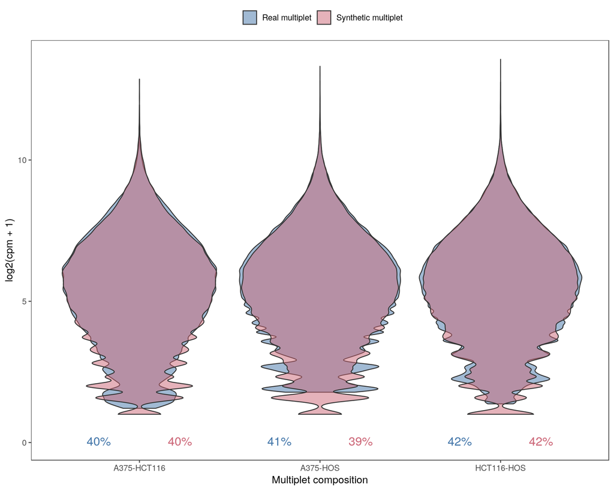

```r
p1 <- synth %>%
    inner_join(mul, by = c("gene", "cellTypes")) %>%
    gather(type, value, -(gene:syntheticMultipletID), -sample) %>%
    filter(cellTypes != "A375-HCT116-HOS") %>%
    mutate(type = if_else(type == "Counts", "Real multiplet", "Synthetic multiplet")) %>%
    rename(cpm = value) %>%
    ggplot() +
    geom_violin(
      data = . %>% filter(cpm != 0),
      aes(cellTypes, log2(cpm + 1), fill = type), alpha = 0.5, position = position_identity()
    ) +
    geom_text(
      data = . %>%
      group_by(cellTypes, type) %>%
      summarize(do = paste0(round(length(which(cpm == 0)) / n(), digits = 2) * 100, "%")),
      aes(cellTypes, 0.05, label = do, group = type, colour = type),
      size = 5, position = position_dodge(width = 0.9)
    ) +
    scale_colour_ptol() +
    scale_fill_ptol() +
    labs(x = "Multiplet composition") +
    theme_few() +
    theme(legend.position = "top", legend.justification = "center") +
    guides(fill = guide_legend(title = ""), colour = FALSE)

p1
```

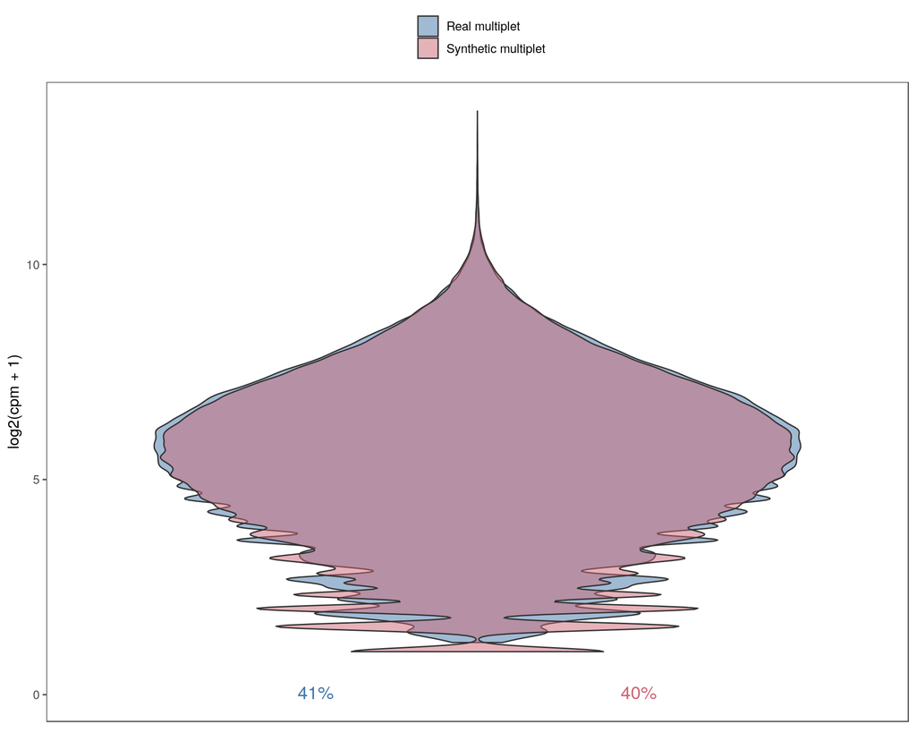

```r
p2 <- synth %>%
    inner_join(mul, by = c("gene", "cellTypes")) %>%
    gather(type, value, -(gene:syntheticMultipletID), -sample) %>%
    filter(cellTypes != "A375-HCT116-HOS") %>%
    mutate(type = if_else(type == "Counts", "Real multiplet", "Synthetic multiplet")) %>%
    rename(cpm = value) %>%
    ggplot() +
    geom_violin(
      data = . %>% filter(cpm != 0),
      aes("x", log2(cpm + 1), fill = type), alpha = 0.5, position = position_identity()
    ) +
    geom_text(
      data = . %>%
      group_by(type) %>%
      summarize(do = paste0(round(length(which(cpm == 0)) / n(), digits = 2) * 100, "%")),
      aes("x", 0.05, label = do, group = type, colour = type),
      size = 5, position = position_dodge(width = 0.9)
    ) +
    scale_colour_ptol() +
    scale_fill_ptol() +
    theme_few() +
    theme(
      legend.position = "top",
      legend.justification = "center",
      axis.text.x = element_blank(),
      axis.ticks.x = element_blank(),
      axis.title.x = element_blank()
    ) +
    guides(fill = guide_legend(title = "", nrow = 2), colour = FALSE)

p2
```

```r
ggsave(
  plot = p2,
  filename = '../figures/figure1.pdf',
  device = cairo_pdf,
  height = 180,
  width = 50,
  units = "mm"
)
```

### Adjusting multiplet contribution

Synthesize 25 multiplets for each combination and reduce the contribution of HOS cells by 0%, 25%, 50%, 75%, or 99%. Calculate the mean gene expression of 25 cell type specific genes for each combination and plot together with the real multiplets and corresponding singlets.

Show genes used in figure.

```r
#find overexpressed genes in each cell type
genes <- SCM.Meta %>%
  filter(cellNumber == "Singlet") %>%
  rename(class = cellTypes) %>%
  foldChangePerClass(CIMseq:::.norm.counts(sng), .) %>%
  matrix_to_tibble("gene") %>%
  select(gene, A375, HCT116, HOS) %>%
  gather(geneType, fold, -gene) %>%
  filter(!is.na(fold) & !is.infinite(fold)) %>%
  group_by(geneType) %>%
  top_n(25, fold) %>%
  ungroup()

as.data.frame(genes)
```

| gene | geneType | fold |
| --- | --- | --- |
| AKR1C2 | A375 | 842.7916 |
| C3orf14 | A375 | 540.4661 |
| CD74 | A375 | 7035.0083 |
| CSAG1 | A375 | 371.5075 |
| FRMD3 | A375 | 722.7039 |
| HAPLN1 | A375 | 516.5191 |
| HLA-DPA1 | A375 | 345.8835 |
| HLA-DQB1 | A375 | 1128.0633 |
| HLA-DRA | A375 | 888.5221 |
| IL13RA2 | A375 | 27412.8086 |
| IL24 | A375 | 589.0381 |
| MAGEA12 | A375 | 4223.9938 |
| MAGEA4 | A375 | 7861.3687 |
| NFATC2 | A375 | 389.8805 |
| NTM | A375 | 348.2732 |
| PLP1 | A375 | 6040.5886 |
| S100B | A375 | 1362.4660 |
| SLAMF7 | A375 | 443.0850 |
| SLC6A15 | A375 | 4502.4477 |
| SOX6 | A375 | 396.6667 |
| SPP1 | A375 | 294.5634 |
| UCN2 | A375 | 569.1335 |
| ZNF208 | A375 | 332.8525 |
| ZNF626 | A375 | 337.5129 |
| ZNF682 | A375 | 423.1920 |
| ACSL5 | HCT116 | 633.1311 |
| ADIRF | HCT116 | 817.3108 |
| CLDN4 | HCT116 | 598.1730 |
| CLDN7 | HCT116 | 893.2992 |
| CST6 | HCT116 | 198.4286 |
| DEF6 | HCT116 | 243.4168 |
| DENND2D | HCT116 | 583.9756 |
| EHF | HCT116 | 234.0127 |
| ELOVL7 | HCT116 | 321.5629 |
| EREG | HCT116 | 8996.4439 |
| GPAT2 | HCT116 | 354.2367 |
| HBE1 | HCT116 | 218.2478 |
| HS3ST1 | HCT116 | 275.1844 |
| HSBP1L1 | HCT116 | 1823.1595 |
| KRT19 | HCT116 | 1216.3940 |
| MAL2 | HCT116 | 712.0234 |
| MPZL2 | HCT116 | 250.9480 |
| PRF1 | HCT116 | 190.7474 |
| RAC2 | HCT116 | 223.5593 |
| SERPINB9 | HCT116 | 224.8890 |
| SFN | HCT116 | 597.5689 |
| SKAP1 | HCT116 | 262.9111 |
| SPINT2 | HCT116 | 1524.0650 |
| ST14 | HCT116 | 3780.6140 |
| SYTL3 | HCT116 | 541.5495 |
| ACTG2 | HOS | 408.4888 |
| BNC1 | HOS | 326.3448 |
| CCDC144CP | HOS | 1884.2215 |
| CLDN11 | HOS | 848.0553 |
| COL1A1 | HOS | 1578.2840 |
| COL1A2 | HOS | 713.1096 |
| COL5A1 | HOS | 714.4830 |
| COL8A1 | HOS | 979.7977 |
| CREB3L1 | HOS | 847.8271 |
| DKK3 | HOS | 960.8348 |
| EPHA5 | HOS | 732.1071 |
| FBN2 | HOS | 307.7543 |
| GFRA1 | HOS | 500.7859 |
| IGFBPL1 | HOS | 845.6487 |
| LOC339166 | HOS | 451.3150 |
| LUM | HOS | 7337.7884 |
| LXN | HOS | 305.7637 |
| MFAP4 | HOS | 975.1633 |
| MME | HOS | 1492.6498 |
| MT1M | HOS | 665.4003 |
| NID2 | HOS | 479.2335 |
| PCBP3 | HOS | 525.4787 |
| PLBD1 | HOS | 1405.1397 |
| UCHL1 | HOS | 14487.2222 |
| ZNF660 | HOS | 484.9536 |

Plot figure.

```r
###FUNCTIONS
#function to calculate the mean gene expression for a specific cell type.
typeMeans <- function(type) {
  SCM.Meta %>%
    filter(cellTypes == type) %>%
    pull(sample) %>%
    {SCM.Counts[, colnames(SCM.Counts) %in% .]} %>%
    norm() %>%
    rowMeans2() %>%
    tibble(gene = rownames(SCM.Counts), counts = .) %>%
    mutate(cellType = type)
}

#Synthesize 25 multiplets with varying levels of adjusted HOS input
#Calculate the mean gene expression in the 25 multiplets for each condition
s <- str_detect(colnames(SCM.Counts), "^s")
sng <- SCM.Counts[, s]
classes <- slice(SCM.Meta, match(colnames(sng), SCM.Meta$sample))$cellTypes

#setup fractions
.assignFractions <- function(ct, adj) {
  vec <- rep(0, length(unique(classes)))
  names(vec) <- sort(unique(classes))
  if("HOS" %in% ct) {
    vec[names(vec) == "HOS"] <- 1/length(ct) * adj
    vec[names(vec) %in% ct[ct != "HOS"]] <- (1 - sum(vec)) / length(ct[ct != "HOS"])
  } else {
    vec[names(vec) %in% ct] <- 1/length(ct)
    vec[!names(vec) %in% ct] <- (1 - sum(vec)) / length(which(vec == 0))
  }
  vec
}

adj <- c(1, 0.75, 0.5, 0.25, 0.01)
n <- 25

combos <- unique(classes) %>%
  sort() %>%
  combn(2) %>%
  as.data.frame(stringsAsFactors = FALSE) %>%
  {paste(.[1, ], .[2, ], sep = "-")}

set.seed(195)
fractions <- tibble(
  cellType = rep(combos, each = length(adj) * n),
  adjustment = rep(adj, length(combos) * n),
  ns = rep(rep(1:n, each = length(adj), length(combos)))
) %>%
  mutate(cellTypes = map(cellType, function(x) str_split(x, "-")[[1]])) %>%
  mutate(fractions = map2(cellTypes, adjustment, ~.assignFractions(.x, .y))) %>%
  mutate(seed = runif(1, 1, 99999) + 1:n())

#synthesize multiplets
synth <- fractions %>%
  mutate(sm = map2(fractions, seed, function(f, s) {
    syntheticMultipletsFromCounts(norm(sng), classes, f, seed = s) %>%
      matrix_to_tibble("gene") %>%
      mutate(gene = rownames(SCM.Counts)) #HERE
  })) %>%
  select(cellType, adjustment, ns, sm) %>%
  unnest() %>%
  group_by(cellType, adjustment, gene) %>%
  summarize(counts_synthetic = mean(V1)) %>%
  ungroup() %>%
  spread(adjustment, counts_synthetic) %>%
  setNames(c(
    "cellType", "gene",
    paste0("HOS reduced ", (1 - as.numeric(colnames(.)[-c(1:2)])) * 100, "%")
  ))

#calculate the mean gene expression for each type of singlet
realSng <- map_dfr(c("A375", "HCT116", "HOS"), typeMeans)

#calculate the mean gene expression for each type of multiplet
realMul <- map_dfr(c("A375-HCT116", "A375-HOS", "HCT116-HOS"), typeMeans) %>%
  rename(Multiplet = counts) %>%
  separate(cellType, into = c("cellType1", "cellType2"), sep = "-", remove = FALSE)

#concatenate real singlet, real multiplet, and info for genes corresponding to
#a cell type
realData <- realMul %>%
  inner_join(realSng, by = c("cellType1" = "cellType", "gene" = "gene")) %>%
  inner_join(realSng, by = c("cellType2" = "cellType", "gene" = "gene")) %>%
  rename(counts_cellType1 = counts.x, counts_cellType2 = counts.y) %>%
  inner_join(genes, by = "gene") %>%
  filter(geneType == cellType1 | geneType == cellType2) %>%
  select(
    gene, geneType, cellType, cellType1, cellType2,
    counts_cellType1, counts_cellType2, Multiplet
  )

#concatenate real and synthetic data and prepare for plotting
plotData <- realData %>%
  inner_join(synth, by = c("gene", "cellType")) %>%
  gather(cpmType, cpm, -gene, -geneType, -cellType, -cellType1, -cellType2) %>%
  mutate(cpmType = case_when(
    cpmType == "counts_cellType1" ~ paste0(cellType1, " singlets"),
    cpmType == "counts_cellType2" ~ paste0(cellType2, " singlets"),
    cpmType == "Multiplet" ~ paste0(cellType, " multiplets"),
    TRUE ~ cpmType
  )) %>%
  mutate(cpmType = parse_factor(cpmType, levels = c(
      "A375-HOS multiplets", "HCT116-HOS multiplets", "A375-HCT116 multiplets",
      "HOS reduced 0%", "HOS reduced 25%", "HOS reduced 50%", "HOS reduced 75%",
      "HOS reduced 99%", "A375 singlets", "HCT116 singlets", "HOS singlets"
  ))) %>%
  mutate(plotGene = paste0(gene, " (", geneType, ")")) %>%
  mutate(plotGene = parse_factor(plotGene, levels = unique(plotGene))) %>%
  mutate(cellType = parse_factor(cellType, levels = c("A375-HOS", "HCT116-HOS", "A375-HCT116", "A375-HCT116-HOS")))
```

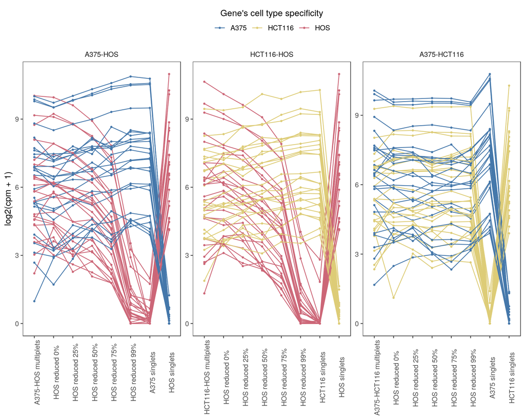

```r
p3 <- plotData %>%
  ggplot() +
  geom_line(aes(cpmType, log2(cpm + 1), group = gene, colour = geneType)) +
  geom_point(aes(cpmType, log2(cpm + 1), colour = geneType), size = 0.75) +
  facet_wrap(~cellType, scales = "free") +
  theme_few() +
  ggthemes::scale_colour_ptol() +
  theme(
    axis.title.x = element_blank(),
    axis.text.x = element_text(angle = 90),
    legend.position = "top"
  ) +
  guides(colour = guide_legend(
    title = "Gene's cell type specificity",
    title.position = "top",
    title.hjust = 0.5)
  )

p3
```

```r
ggsave(
  plot = p3,
  filename = '../figures/figure2.pdf',
  device = cairo_pdf,
  height = 180,
  width = 240,
  units = "mm"
)
```

```r
p3 <- plotData %>%
  group_by(cpmType, cellType, geneType) %>%
  summarize(m = mean(cpm)) %>%
  ggplot() +
  geom_line(aes(cpmType, log2(m + 1), group = geneType, colour = geneType)) +
  geom_point(aes(cpmType, log2(m + 1), colour = geneType), size = 0.75) +
  facet_wrap(~cellType, scales = "free") +
  theme_bw() +
  ggthemes::scale_colour_ptol() +
  theme(
    axis.title.x = element_blank(),
    axis.text.x = element_text(angle = 90),
    legend.position = "top"
  ) +
  guides(colour = guide_legend(
    title = "Gene's cell type specificity",
    title.position = "top",
    title.hjust = 0.5)
  )

p3

ggsave(
  plot = p3,
  filename = '../figures/figure2.pdf',
  device = cairo_pdf,
  height = 180,
  width = 240,
  units = "mm"
)
```

[output not shown]

The results show a minimal change in gene expression between the sorted multiplets and the non-adjusted (0%) multiplets (first two columns). In addition, the specificity of the genes for the individual cell types is easily recognized (last two columns). Finally, it can be seen that decreasing levels of HOS input into the synthetic multiplets causes a concomitatnt decrease in HOS specific gene expression in synthetic multiplets including the HOS cell type. On the other hand, in multiplets that do not include HOS cells, the gene expression of the HOS genes cause no changes in gene expression.

In summary, the results indicate that the algroithm for generating synthetic multiplets is capable of mirroring the gene expression profile in multiplets of a known composition. Furthermore, adjusting the input of a specific cell type in the multiplet results in the expected changes in the multiplets gene expression.